# Exercise 4: Clustering and classification

This exercise focuses on clustering and classification methods, such as linear discriminant analysis and k-means clustering. Our research focuses on the crime rate in Boston suburbs.

## Data

Our dataset “Boston” is a data frame containing 14 variables and 506 observations on the housing values in the suburbs of Boston. The variables contain factors such as per capita crime rate by town, nitrogen oxides concentration and pupil-teacher ratio by town.

```
## 'data.frame':    506 obs. of  14 variables:
##  $ crim   : num  0.00632 0.02731 0.02729 0.03237 0.06905 ...
##  $ zn     : num  18 0 0 0 0 0 12.5 12.5 12.5 12.5 ...
##  $ indus  : num  2.31 7.07 7.07 2.18 2.18 2.18 7.87 7.87 7.87 7.87 ...
##  $ chas   : int  0 0 0 0 0 0 0 0 0 0 ...
##  $ nox    : num  0.538 0.469 0.469 0.458 0.458 0.458 0.524 0.524 0.524 0.524 ...
##  $ rm     : num  6.58 6.42 7.18 7 7.15 ...
##  $ age    : num  65.2 78.9 61.1 45.8 54.2 58.7 66.6 96.1 100 85.9 ...
##  $ dis    : num  4.09 4.97 4.97 6.06 6.06 ...
##  $ rad    : int  1 2 2 3 3 3 5 5 5 5 ...
##  $ tax    : num  296 242 242 222 222 222 311 311 311 311 ...
##  $ ptratio: num  15.3 17.8 17.8 18.7 18.7 18.7 15.2 15.2 15.2 15.2 ...
##  $ black  : num  397 397 393 395 397 ...
##  $ lstat  : num  4.98 9.14 4.03 2.94 5.33 ...
##  $ medv   : num  24 21.6 34.7 33.4 36.2 28.7 22.9 27.1 16.5 18.9 ...
```

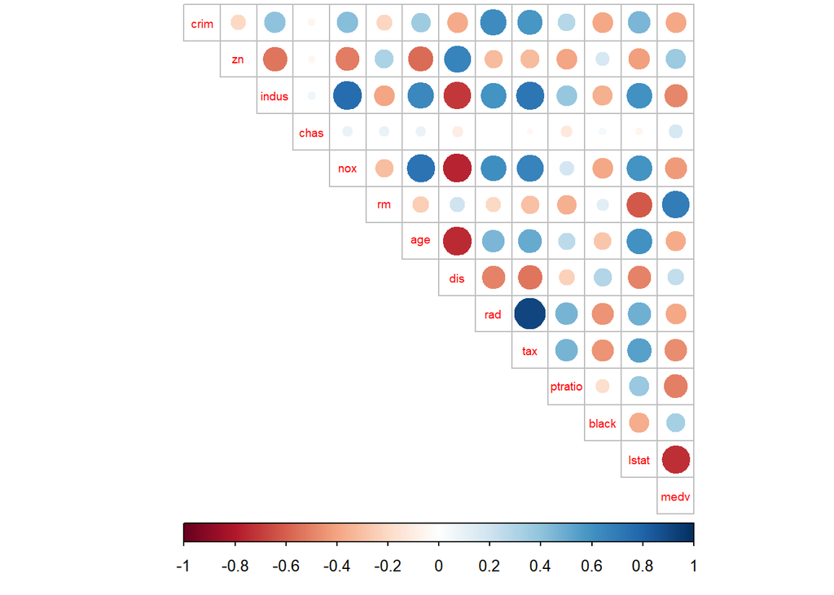

```r
# 3.
# visualizing the data
cor_matrix <- cor(Boston)

# library(corrplot) or
corrplot::corrplot(cor_matrix, method="circle", type="upper", cl.pos="b", tl.pos="d", tl.cex=0.6)
```

```r
# summary of variables
summary(Boston)
```

```
##       crim                zn             indus            chas
##  Min.   : 0.00632   Min.   :  0.00   Min.   : 0.46   Min.   :0.00000
##  1st Qu.: 0.08204   1st Qu.:  0.00   1st Qu.: 5.19   1st Qu.:0.00000
##  Median : 0.25651   Median :  0.00   Median : 9.69   Median :0.00000
##  Mean   : 3.61352   Mean   : 11.36   Mean   :11.14   Mean   :0.06917
##  3rd Qu.: 3.67708   3rd Qu.: 12.50   3rd Qu.:18.10   3rd Qu.:0.00000
##  Max.   :88.97620   Max.   :100.00   Max.   :27.74   Max.   :1.00000
##       nox               rm             age              dis
##  Min.   :0.3850   Min.   :3.561   Min.   :  2.90   Min.   : 1.130
##  1st Qu.:0.4490   1st Qu.:5.886   1st Qu.: 45.02   1st Qu.: 2.100
##  Median :0.5380   Median :6.208   Median : 77.50   Median : 3.207
##  Mean   :0.5547   Mean   :6.285   Mean   : 68.57   Mean   : 3.795
##  3rd Qu.:0.6240   3rd Qu.:6.623   3rd Qu.: 94.08   3rd Qu.: 5.188
##  Max.   :0.8710   Max.   :8.780   Max.   :100.00   Max.   :12.127
##       rad              tax           ptratio          black
##  Min.   : 1.000   Min.   :187.0   Min.   :12.60   Min.   :  0.32
##  1st Qu.: 4.000   1st Qu.:279.0   1st Qu.:17.40   1st Qu.:375.38
##  Median : 5.000   Median :330.0   Median :19.05   Median :391.44
##  Mean   : 9.549   Mean   :408.2   Mean   :18.46   Mean   :356.67
##  3rd Qu.:24.000   3rd Qu.:666.0   3rd Qu.:20.20   3rd Qu.:396.23
##  Max.   :24.000   Max.   :711.0   Max.   :22.00   Max.   :396.90
##      lstat            medv
##  Min.   : 1.73   Min.   : 5.00
##  1st Qu.: 6.95   1st Qu.:17.02
##  Median :11.36   Median :21.20
##  Mean   :12.65   Mean   :22.53
##  3rd Qu.:16.95   3rd Qu.:25.00
##  Max.   :37.97   Max.   :50.00
```

**Figure 1.** Correlation matrix of the entire Boston data frame.

Notably positive correlations can be observed between index of accessibility to radial highways and full-value property-tax rate per $10,000. Also proportion of non-retail business acres per town and nitrogen oxides concentration (parts per 10 million) correlate positively as well as index of accessibility to radial highways and per capita crime rate by town.

## Analysis

### Standardizing the data

```r
# 4.
# standardizing the dataset
boston_scaled <- scale(Boston)
boston_scaled <- as.data.frame(boston_scaled)

# categorizing the crime rate
bins <- quantile(boston_scaled$crim)
crime <- cut(boston_scaled$crim, breaks = bins, include.lowest = TRUE, labels=c("low", "med_low", "med_high", "high"))

#replacing the old crime rate with the categorized variable
boston_scaled <- dplyr::select(boston_scaled, -crim)
boston_scaled <- data.frame(boston_scaled, crime)
summary(boston_scaled)
```

```
##        zn               indus              chas              nox
##  Min.   :-0.48724   Min.   :-1.5563   Min.   :-0.2723   Min.   :-1.4644
##  1st Qu.:-0.48724   1st Qu.:-0.8668   1st Qu.:-0.2723   1st Qu.:-0.9121
##  Median :-0.48724   Median :-0.2109   Median :-0.2723   Median :-0.1441
##  Mean   : 0.00000   Mean   : 0.0000   Mean   : 0.0000   Mean   : 0.0000
##  3rd Qu.: 0.04872   3rd Qu.: 1.0150   3rd Qu.:-0.2723   3rd Qu.: 0.5981
##  Max.   : 3.80047   Max.   : 2.4202   Max.   : 3.6648   Max.   : 2.7296
##        rm               age               dis               rad
##  Min.   :-3.8764   Min.   :-2.3331   Min.   :-1.2658   Min.   :-0.9819
##  1st Qu.:-0.5681   1st Qu.:-0.8366   1st Qu.:-0.8049   1st Qu.:-0.6373
##  Median :-0.1084   Median : 0.3171   Median :-0.2790   Median :-0.5225
##  Mean   : 0.0000   Mean   : 0.0000   Mean   : 0.0000   Mean   : 0.0000
##  3rd Qu.: 0.4823   3rd Qu.: 0.9059   3rd Qu.: 0.6617   3rd Qu.: 1.6596
##  Max.   : 3.5515   Max.   : 1.1164   Max.   : 3.9566   Max.   : 1.6596
##       tax             ptratio            black             lstat
##  Min.   :-1.3127   Min.   :-2.7047   Min.   :-3.9033   Min.   :-1.5296
##  1st Qu.:-0.7668   1st Qu.:-0.4876   1st Qu.: 0.2049   1st Qu.:-0.7986
##  Median :-0.4642   Median : 0.2746   Median : 0.3808   Median :-0.1811
##  Mean   : 0.0000   Mean   : 0.0000   Mean   : 0.0000   Mean   : 0.0000
##  3rd Qu.: 1.5294   3rd Qu.: 0.8058   3rd Qu.: 0.4332   3rd Qu.: 0.6024
##  Max.   : 1.7964   Max.   : 1.6372   Max.   : 0.4406   Max.   : 3.5453
##       medv              crime
##  Min.   :-1.9063   low     :127
##  1st Qu.:-0.5989   med_low :126
##  Median :-0.1449   med_high:126
##  Mean   : 0.0000   high    :127
##  3rd Qu.: 0.2683
##  Max.   : 2.9865
```

Above you can find a summary of the scaled dataset and categorized crime rate. After the scaling of the dataset and categorization of the crime rate variable, we will divide the data set into train (80 %) and test (20 %) sets.

```r
# dividing the train and test sets
n <- nrow(boston_scaled)
ind <- sample(n,  size = n * 0.8)
train <- boston_scaled[ind,]
test <- boston_scaled[-ind,]
```

### Classification

```r
# 5. fitting an LDA on the train set
lda.fit <- lda(train$crime ~ ., data = train)
lda.fit
```

```
## Call:
## lda(train$crime ~ ., data = train)
##
## Prior probabilities of groups:
##       low   med_low  med_high      high
## 0.2500000 0.2351485 0.2500000 0.2648515
##
## Group means:
##                  zn      indus        chas        nox          rm
## low       0.9487194 -0.9067811 -0.11640431 -0.8734288  0.40748537
## med_low  -0.1090187 -0.3221930  0.05921622 -0.6014628 -0.10563913
## med_high -0.3751653  0.1806410  0.07850165  0.3601270  0.07595262
## high     -0.4872402  1.0170108 -0.12514775  1.0632086 -0.37742573
##                 age        dis        rad        tax    ptratio      black
## low      -0.8738426  0.8719966 -0.7066939 -0.7336253 -0.4267315  0.3717128
## med_low  -0.3357023  0.3744687 -0.5599607 -0.5354141 -0.1102529  0.3291840
## med_high  0.3936761 -0.3640465 -0.4644925 -0.3271573 -0.2191027  0.1021424
## high      0.8305595 -0.8606459  1.6392096  1.5148289  0.7820356 -0.7363520
##                lstat        medv
## low      -0.76664336  0.50853993
## med_low  -0.15790223  0.04290069
## med_high -0.02104603  0.16630995
## high      0.93267664 -0.73866229
##
## Coefficients of linear discriminants:
##                 LD1         LD2         LD3
## zn       0.11018873  0.69331206 -0.97538562
## indus   -0.01575362 -0.28730648  0.42322378
## chas    -0.02431516  0.02748144  0.21380677
## nox      0.43489964 -0.73024290 -1.50265181
## rm       0.06504181 -0.02587473 -0.11982045
## age      0.20170950 -0.27388700 -0.01745400
## dis     -0.12841455 -0.19617140  0.21122322
## rad      3.64991516  1.02549890  0.40690771
## tax      0.11054972 -0.06891577  0.07248737
## ptratio  0.15771253 -0.03448806 -0.43417827
## black   -0.06644340  0.03218071  0.12703068
## lstat    0.23176565 -0.27605374  0.37078504
## medv     0.05716946 -0.50146739 -0.23827738
##
## Proportion of trace:
##    LD1    LD2    LD3
## 0.9621 0.0280 0.0099
```

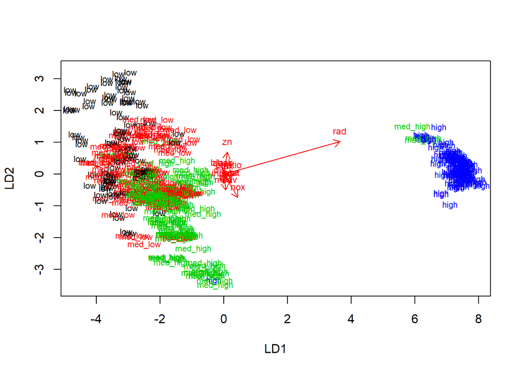

```r
# defining the arrow function
lda.arrows <- function(x, myscale = 1, arrow_heads = 0.1, color = "red", tex = 0.75, choices = c(1,2)){
  heads <- coef(x)
  arrows(x0 = 0, y0 = 0,
         x1 = myscale * heads[,choices[1]],
         y1 = myscale * heads[,choices[2]], col=color, length = arrow_heads)
  text(myscale * heads[,choices], labels = row.names(heads),
       cex = tex, col=color, pos=3)
}

# target classes as numeric (for plotting purposes)
classes <- as.numeric(train$crime)

# plotting the results (paint both lines to execute)
plot(lda.fit, dimen = 2, col=classes, pch=classes)
lda.arrows(lda.fit, myscale = 1)
```

**Figure 2.** The scatter plot of the linear discriminant analysis on crime rate.

Based on our linear discriminant analysis it would seem our crime rate variable is indeed best predicted by index of accessibility to radial highways, a connection we already saw in the correlations.

### Prediction

Next we will attempt to predict the classes of the test data based on our model created above.

```r
# 6.
# saving the crime categories from the test set and then removing the categorical crime variable from the test dataset
correct_classes <- test$crime
test <- dplyr::select(test, -crime)

# predicting the classes with the LDA model on the test data
lda.pred <- predict(lda.fit, newdata = test)

# cross tabulating the results
table(correct = correct_classes, predicted = lda.pred$class)
```

```
##           predicted
## correct    low med_low med_high high
##   low       14      10        2    0
##   med_low    5      14       12    0
##   med_high   0       7       15    3
##   high       0       0        0   20
```

It would seem most of our actual test observations match the model predictions, which validates the model.

### K-means clustering

Next we will reload and scale the Boston data set and use an unsupervised clustering method to assign observations to clusters based on similarity.

```r
# Euclidean distances
dist_eu <- dist(Boston)
summary(dist_eu)
```

```
##    Min. 1st Qu.  Median    Mean 3rd Qu.    Max.
##  0.1343  3.4625  4.8241  4.9111  6.1863 14.3970
```

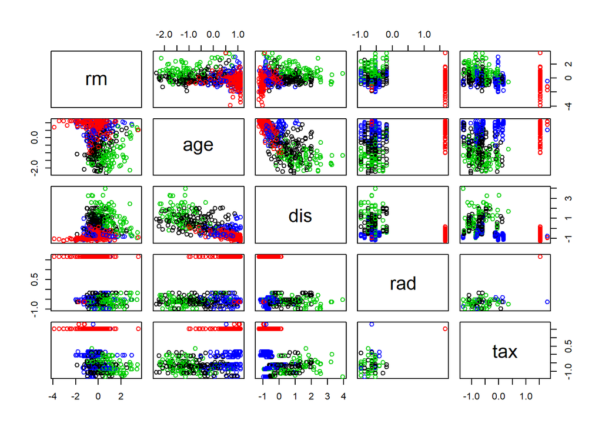

```r
# k-means clustering and plotting
km <-kmeans(Boston, centers = 4)
pairs(Boston[6:10], col = km$cluster)
```

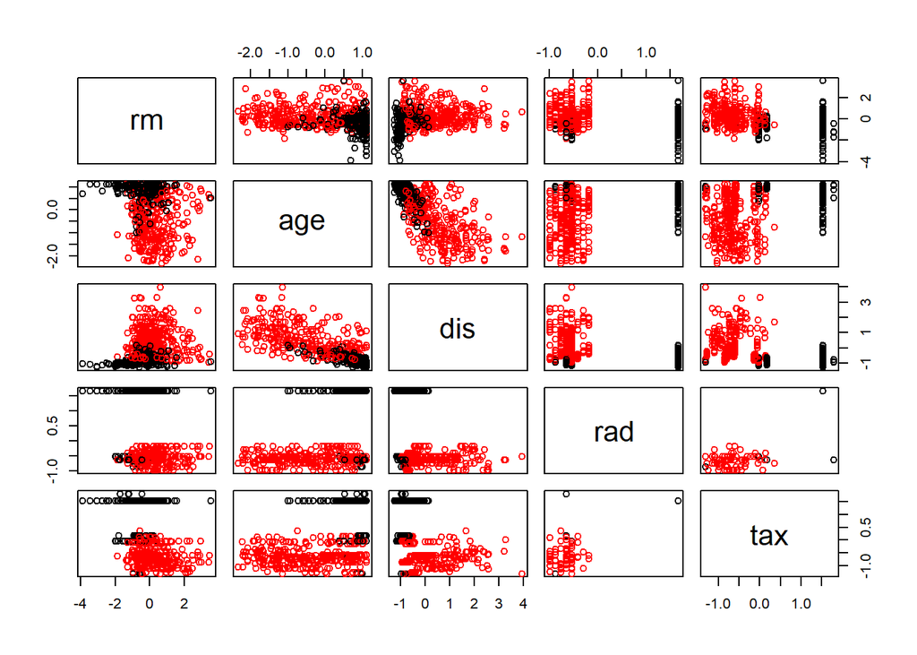

```r
km <-kmeans(Boston, centers = 2)
pairs(Boston[6:10], col = km$cluster)
```

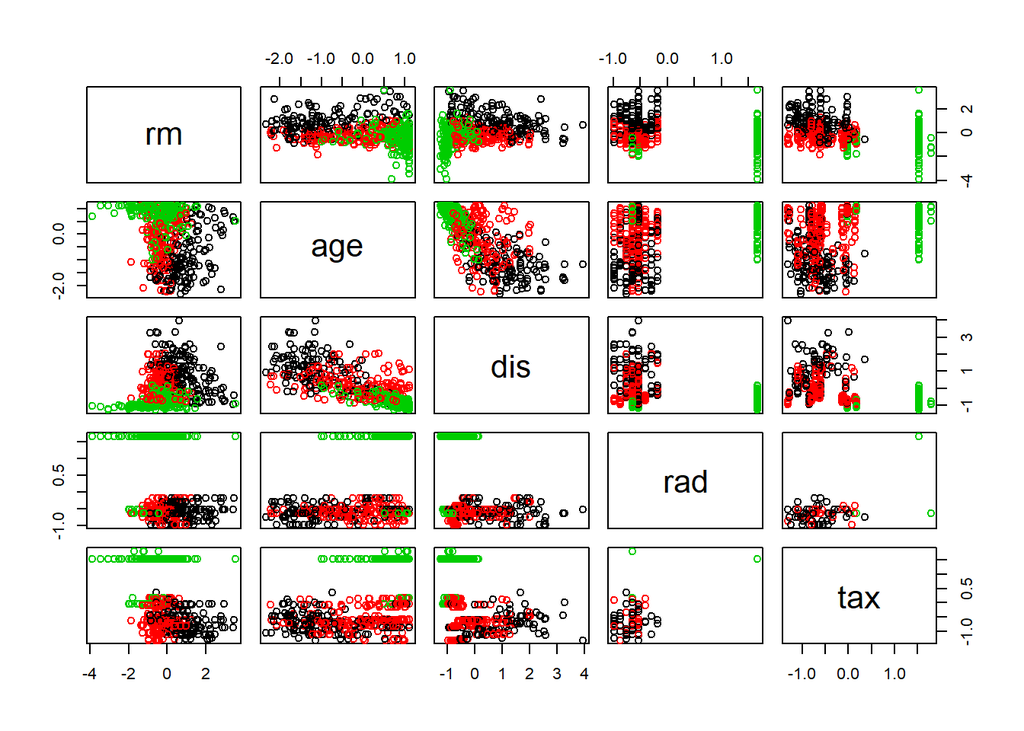

```r
km <-kmeans(Boston, centers = 3)
pairs(Boston[6:10], col = km$cluster)
```